# EDA On Titanic Dataset

Exploratory data analysis on the titanic dataset.

```r
library(ggplot2)
train <- read.csv("C:/Users/hp/Downloads/train.csv")
titanic<- train
Pclass<-as.factor(titanic$Pclass)
Sex<- as.factor(titanic$Sex)
titanic$Survived<- as.factor(titanic$Survived)
```

We can see the summary statistics of the titanic dataset.

```r
summary(titanic)
```

```
##   PassengerId    Survived     Pclass
##  Min.   :  1.0   0:549    Min.   :1.000
##  1st Qu.:223.5   1:342    1st Qu.:2.000
##  Median :446.0            Median :3.000
##  Mean   :446.0            Mean   :2.309
##  3rd Qu.:668.5            3rd Qu.:3.000
##  Max.   :891.0            Max.   :3.000
##
##                                     Name         Sex           Age
##  Abbing, Mr. Anthony                  :  1   female:314   Min.   : 0.42
##  Abbott, Mr. Rossmore Edward          :  1   male  :577   1st Qu.:20.12
##  Abbott, Mrs. Stanton (Rosa Hunt)     :  1                Median :28.00
##  Abelson, Mr. Samuel                  :  1                Mean   :29.70
##  Abelson, Mrs. Samuel (Hannah Wizosky):  1                3rd Qu.:38.00
##  Adahl, Mr. Mauritz Nils Martin       :  1                Max.   :80.00
##  (Other)                              :885                NA's   :177
##      SibSp           Parch             Ticket         Fare
##  Min.   :0.000   Min.   :0.0000   1601    :  7   Min.   :  0.00
##  1st Qu.:0.000   1st Qu.:0.0000   347082  :  7   1st Qu.:  7.91
##  Median :0.000   Median :0.0000   CA. 2343:  7   Median : 14.45
##  Mean   :0.523   Mean   :0.3816   3101295 :  6   Mean   : 32.20
##  3rd Qu.:1.000   3rd Qu.:0.0000   347088  :  6   3rd Qu.: 31.00
##  Max.   :8.000   Max.   :6.0000   CA 2144 :  6   Max.   :512.33
##                                   (Other) :852
##          Cabin     Embarked
##             :687    :  2
##  B96 B98    :  4   C:168
##  C23 C25 C27:  4   Q: 77
##  G6         :  4   S:644
##  C22 C26    :  3
##  D          :  3
##  (Other)    :186
```

```r
str(titanic)
```

```
## 'data.frame':    891 obs. of  12 variables:
##  $ PassengerId: int  1 2 3 4 5 6 7 8 9 10 ...
##  $ Survived   : Factor w/ 2 levels "0","1": 1 2 2 2 1 1 1 1 2 2 ...
##  $ Pclass     : int  3 1 3 1 3 3 1 3 3 2 ...
##  $ Name       : Factor w/ 891 levels "Abbing, Mr. Anthony",..: 109 191 358 277 16 559 520 629 417 581 ...
##  $ Sex        : Factor w/ 2 levels "female","male": 2 1 1 1 2 2 2 2 1 1 ...
##  $ Age        : num  22 38 26 35 35 NA 54 2 27 14 ...
##  $ SibSp      : int  1 1 0 1 0 0 0 3 0 1 ...
##  $ Parch      : int  0 0 0 0 0 0 0 1 2 0 ...
##  $ Ticket     : Factor w/ 681 levels "110152","110413",..: 524 597 670 50 473 276 86 396 345 133 ...
##  $ Fare       : num  7.25 71.28 7.92 53.1 8.05 ...
##  $ Cabin      : Factor w/ 148 levels "","A10","A14",..: 1 83 1 57 1 1 131 1 1 1 ...
##  $ Embarked   : Factor w/ 4 levels "","C","Q","S": 4 2 4 4 4 3 4 4 4 2 ...
```

Survival rate in the titanic:

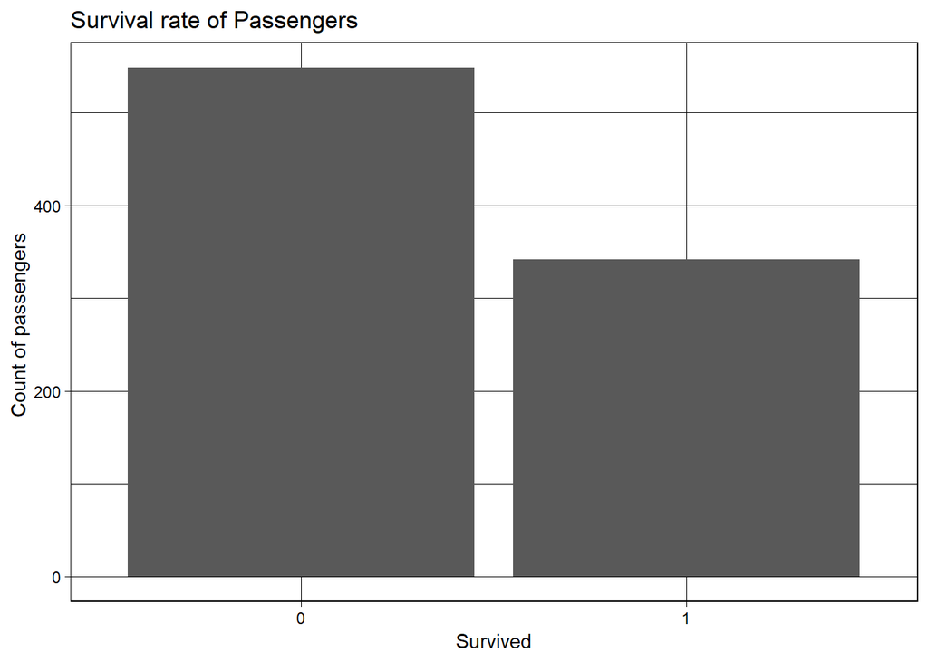

```r
ggplot(data= titanic, aes(x= Survived))+ geom_bar() + theme_linedraw()+
  labs(y= "Count of passengers ", title = "Survival rate of Passengers")
```

We see that unfortunately most of the people died in the tragedy. We can see the exact percentage as well.

```r
prop.table(table(titanic$Survived))
```

```
##
##         0         1
## 0.6161616 0.3838384
```

```r
table(titanic$Sex)
```

```
##
## female   male
##    314    577
```

```r
prop.table(table(titanic$Sex))
```

```
##
##   female     male
## 0.352413 0.647587
```

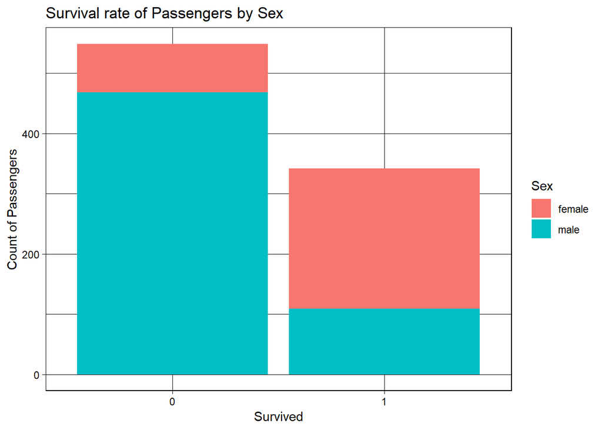

```r
ggplot(data= titanic, aes(x= Survived, fill= Sex))+ geom_bar() + theme_linedraw() +
  labs(y="Count of Passengers", title = "Survival rate of Passengers by Sex")
```

We see from the above visualization that unfortunately, most of the males did not survive in the ship. This means the females were given more priority than the males.

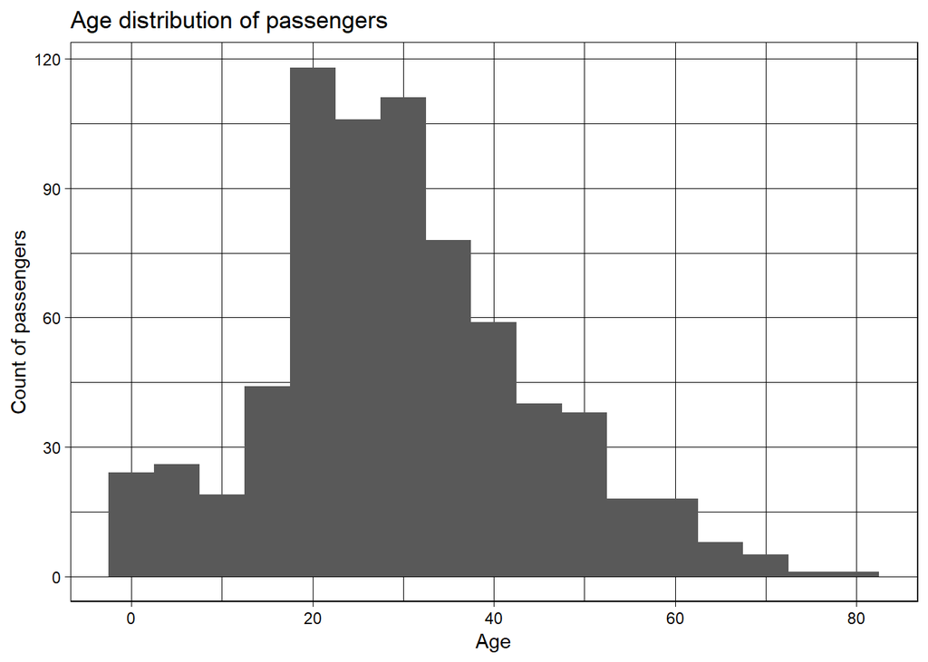

```r
ggplot(data= titanic, aes(x= Age))+ geom_histogram(binwidth = 5)+ theme_linedraw()+
  labs(y= "Count of passengers", title = "Age distribution of passengers")
```

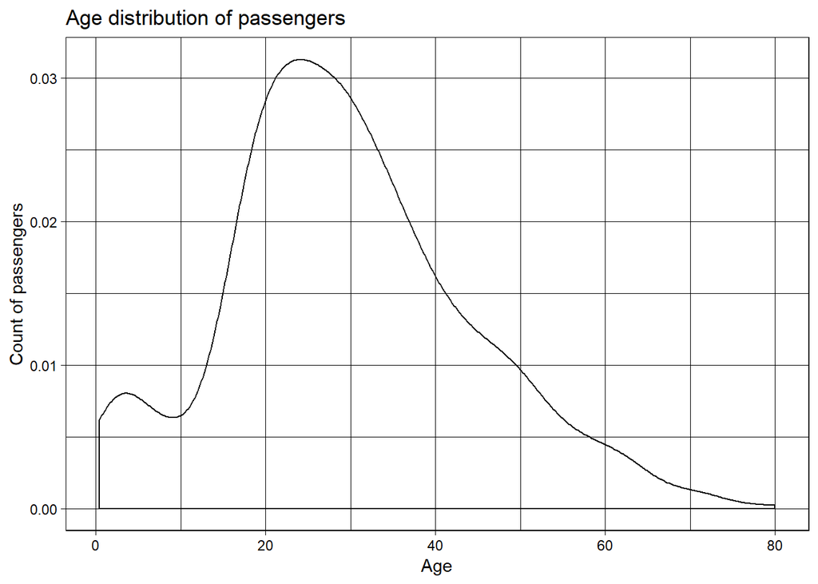

```r
ggplot(data= titanic, aes(x= Age))+ geom_density()+ theme_linedraw()+
  labs(y= "Count of passengers", title = "Age distribution of passengers")
```

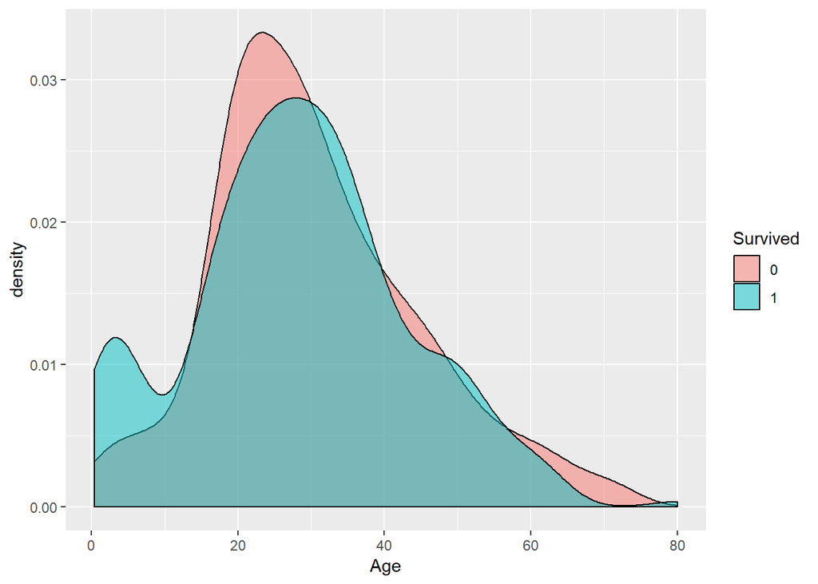

```r
ggplot(data= titanic, aes(x= Age, fill= Survived)) +geom_density(alpha= 0.5)
```

We see that the children survived more than the people of greater age. Unfortunately, people of the age 70-80 years of age did not survive much. We can also see what the Passenger class has to do with the survival rate of the passengers.

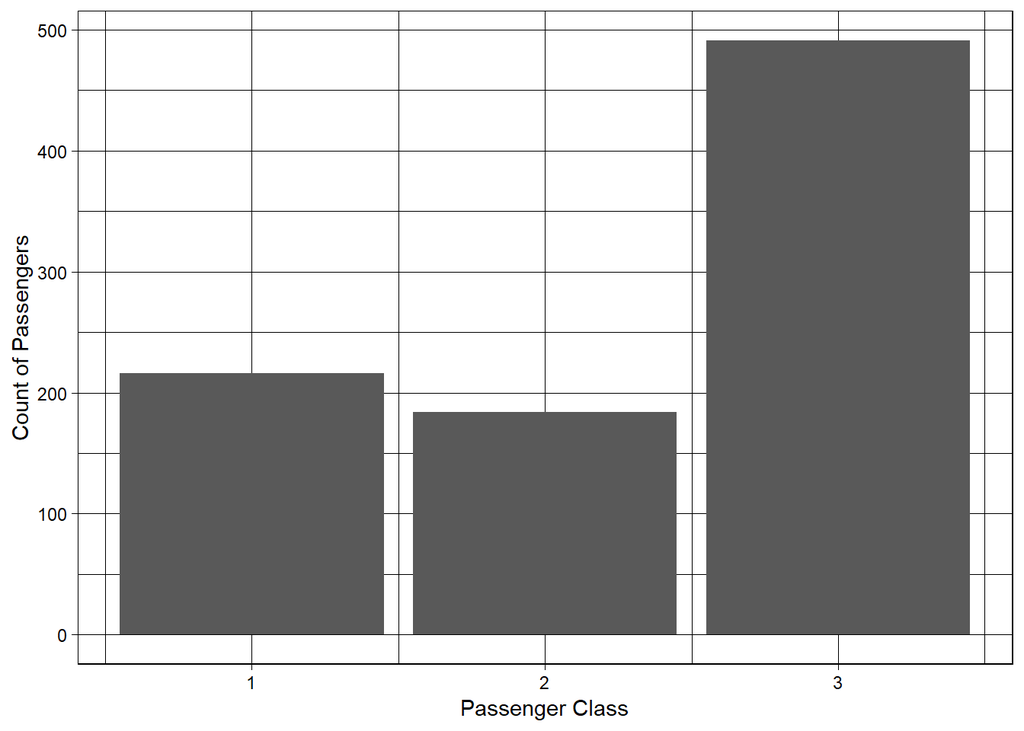

```r
ggplot(data= titanic, aes(x= Pclass))+ geom_bar() + theme_linedraw()+
  labs(x= "Passenger Class", y= "Count of Passengers" )
```

We see that most of the passengers are from the passenger class 3.

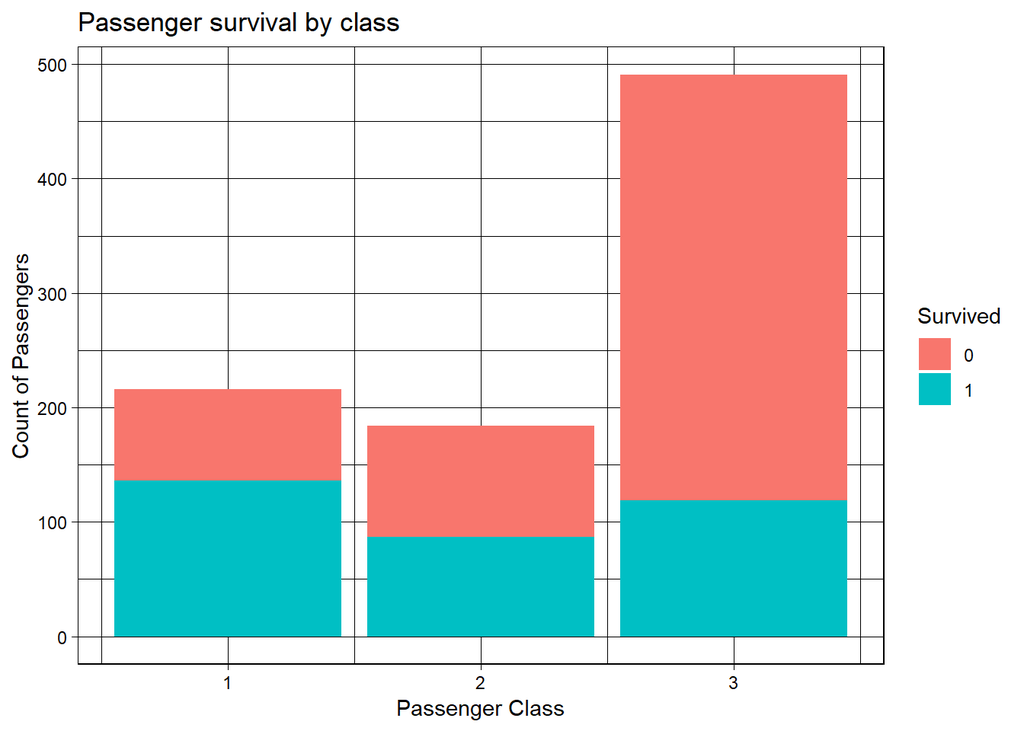

```r
ggplot(data= titanic, aes(x= Pclass, fill= Survived))+ geom_bar() + theme_linedraw()+
  labs(x= "Passenger Class", y= "Count of Passengers", title = "Passenger survival by class" )
```

Here, we see that more percentage of people survived in the passenger class 1 survived than passenger class 2 and passenger class 3.Survival Percentage of people in class 2 is more than the survival percentage in class 3. One possibility is that the life boats could be closer to class 1 than class 2 and class 3. Also, life boats could be closer in class 2 relative to class 3.

We can also see the survival rate of the passengers by class and by the sex.

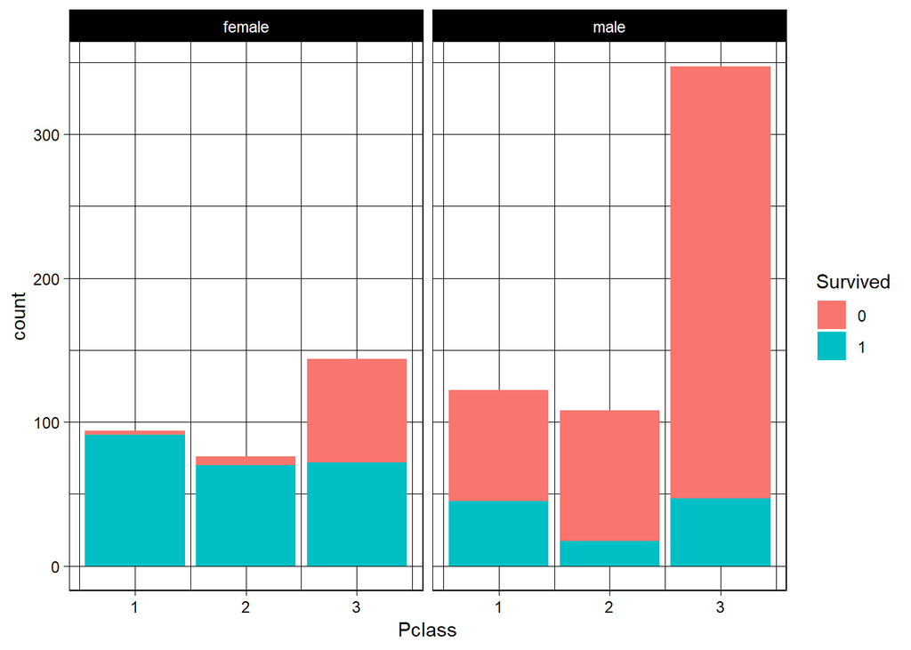

```r
ggplot(data= titanic, aes(x= Pclass, fill= Survived)) +theme_linedraw() + geom_bar() +
  facet_wrap(Sex)
```

We see that almost all the females in class 1 and class 2 survived more than the females in class 3. On the other hand, since males were given less preference than females, the survival rate of males is subtantially lower than the females. Also, here we see that due to the biasness by class, the males who were in the passenger class 3 suffered the most.

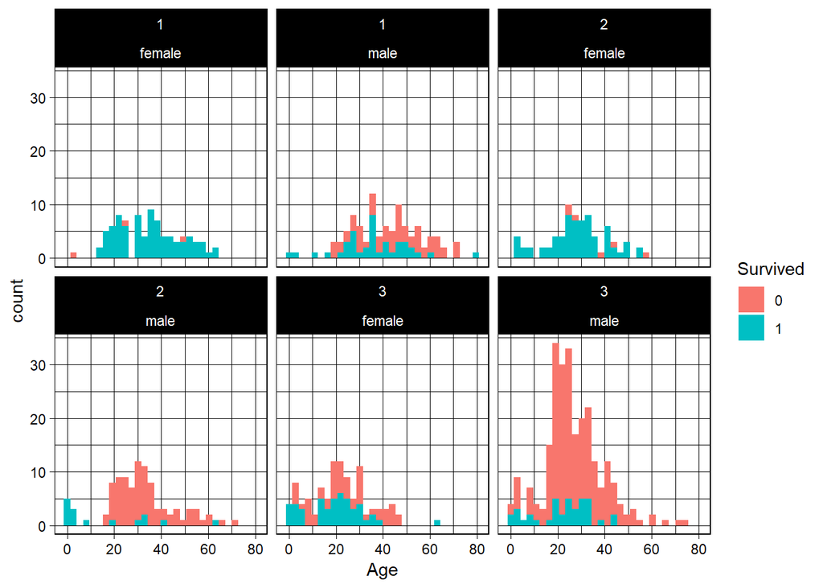

```r
ggplot(data= titanic, aes(x= Age, fill= Survived))+ theme_linedraw() + geom_histogram()+
  facet_wrap(Pclass~ Sex)
```

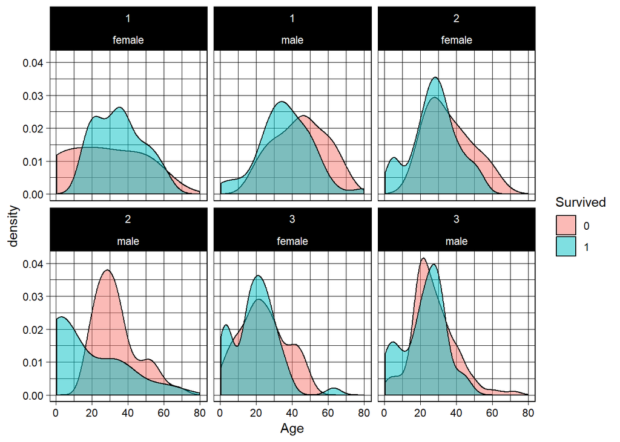

```r
ggplot(data= titanic, aes(x= Age, fill= Survived))+ theme_linedraw() +
  geom_density(alpha= 0.5)+ facet_wrap(Pclass~ Sex)
```

The above two plots give a lot of information about the data. The age factor is also introduced.

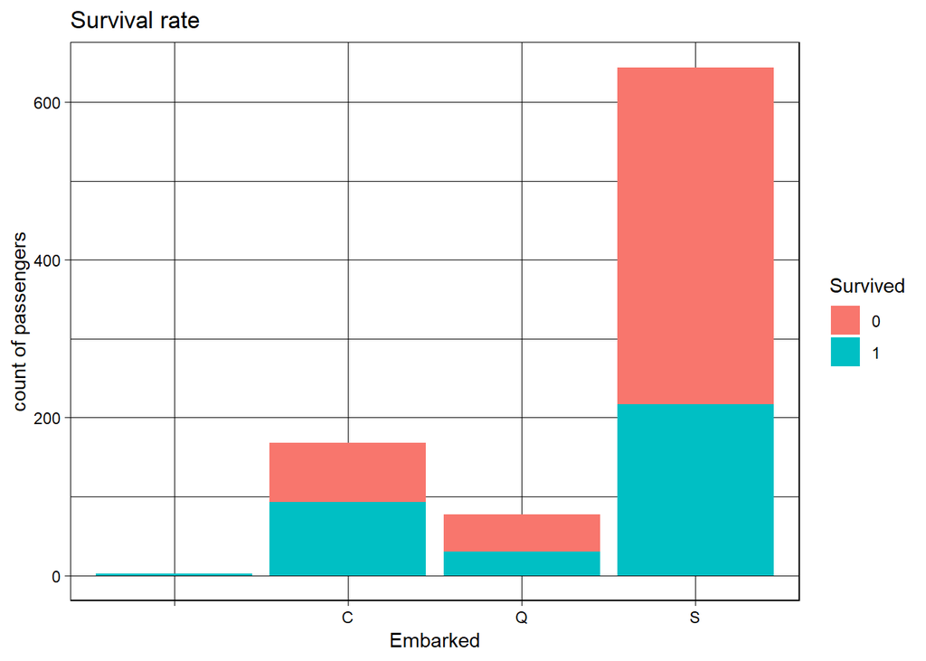

```r
ggplot(data= titanic, aes(x= Embarked, fill= Survived)) + geom_bar() + theme_linedraw() +
  labs(y= "count of passengers", title = "Survival rate ")
```

We see that the point of embarkment of most of the passengers was “S” and more than 50% of the people who embarked from “S” did not survive.